# Reproducible Research Assignment 1

Geons

Sunday, January 10, 2016

## Preparation :

```r
knitr::opts_chunk$set(fig.width=12, fig.height=8, fig.path='figure/',
                      echo=FALSE, warning=FALSE, message=FALSE)
# Clean up before start / tabula rasa (optional)
rm(list=ls())

# Load needed libraries - can be done later as well
library(knitr)
library(plyr)
library(ggplot2)
library(lattice)

# check the workdir and reset if needed
getwd()
```

```
## [1] "E:/reproducible_research/assignment_1"
```

```r
setwd("e:/reproducible_research/assignment_1")
```

## Loading and preprocessing the data

##### 2. Reformat the Date column & eliminate NA’s

## What is mean total number of steps taken per day?

For this part of the assignment, you can ignore the missing values in the dataset.

##### 1. Make a histogram of the total number of steps taken each day

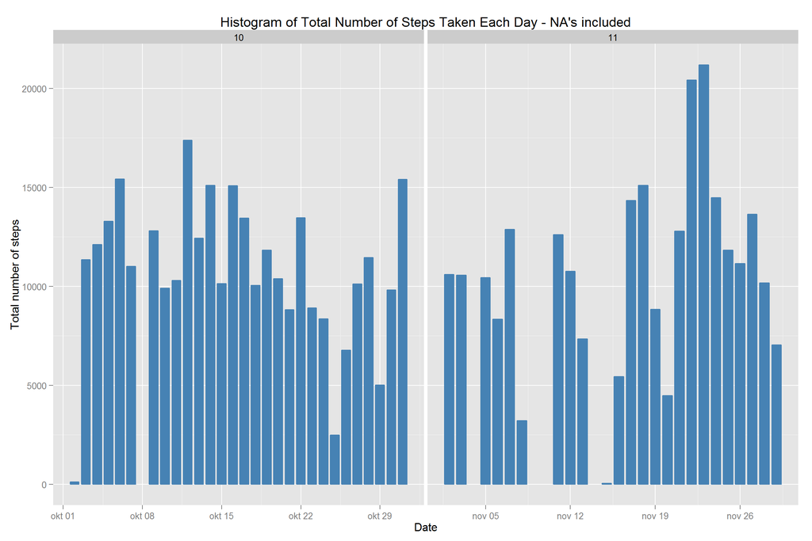

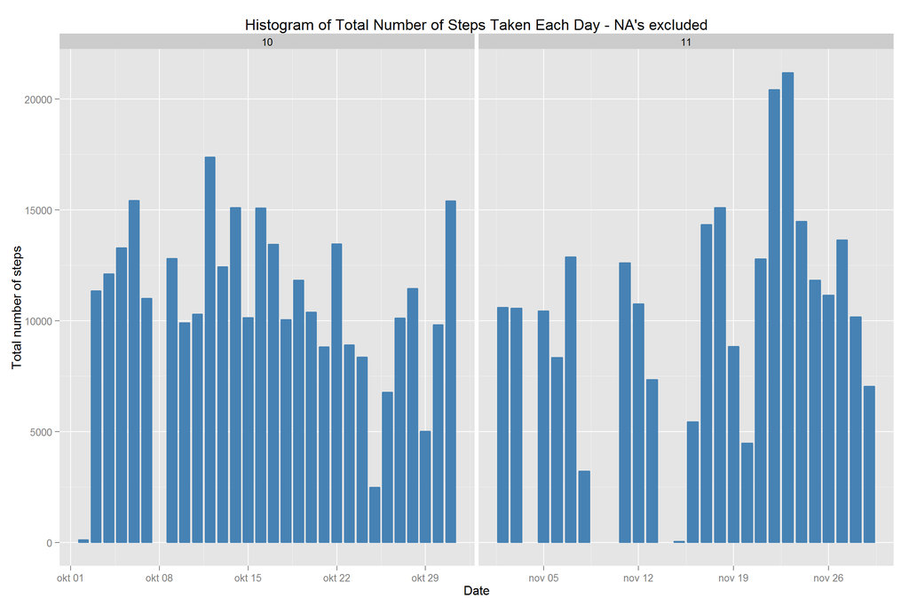

##### 2. Calculate and report the mean and median total number of steps taken per day

The mean total number of steps taken each day is :

```
## [1] 10766.19
```

Median total number of steps taken per day:

```
## [1] 10765
```

## What is the average daily activity pattern?

##### 1. Make a time series plot (i.e. type = “l”) of the 5-minute interval (x-axis) and the average number of steps taken, averaged across all days (y-axis)

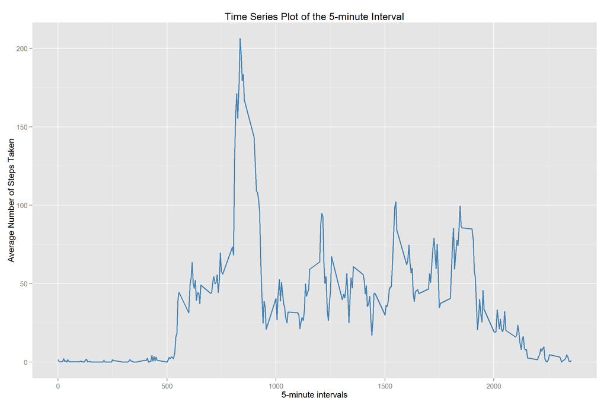

##### 2. Which 5-minute interval, on average across all the days in the dataset, contains the maximum number of steps?

The 5-minute interval that contains on average the most steps is :

```
##     interval meanOfSteps
## 104      835    206.1698
```

## Imputing missing values

```
## [1] 2304
```

##### 2. Devise a strategy for filling in all of the missing values in the dataset. The strategy does not need to be sophisticated.

For example, you could use the mean/median for that day, or the mean for that 5-minute interval, etc.

I chose to use the median for that 5-minute interval to fill each NA value in the steps column. So first i need to create an overview of the median steps

##### 3. Create a new dataset that is equal to the original dataset but with the missing data filled in.

##### 4. Make a histogram of the total number of steps taken each day and Calculate and report the mean and median total number of steps taken per day.

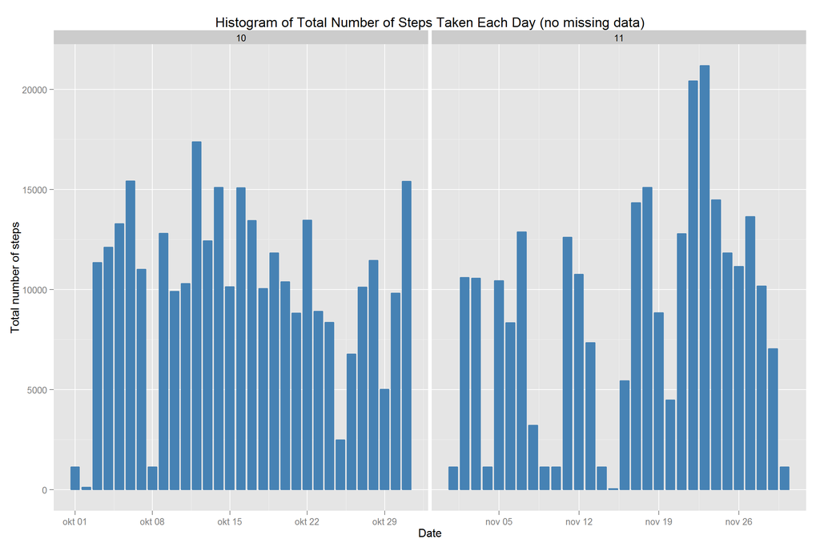

- Do these values differ from the estimates from the first part of the assignment?

Compare them with the two before imputing missing data:

```r
# I started this code block with {r, echo=TRUE, results='show', warning=FALSE, message=TRUE}
# I would put echo = FALSE if it weren't for the assignment ... but hey it's an exercise!
message("Substracting the real mean (", round(realMean), ") from the fake mean (", round(fakeMean), ") gives : ", round(fakeMean - realMean) , " !)")
```

```
## Substracting the real mean (10766) from the fake mean (9504) gives : -1262 !)
```

```r
message("Substracting the real median (", realMedian, ") from the fake median (", fakeMedian, ") gives : ", fakeMedian - realMedian , " !)")
```

```
## Substracting the real median (10765) from the fake median (10395) gives : -370 !)
```

- What is the impact of imputing missing data on the estimates of the total daily number of steps?

After replacing the missing data by the median 5-min interval value, the fake mean of total steps taken per day is 1262 steps less than that of the mean of the recorded data; the new (fake) median of total steps taken per day is 370 steps less than that of the real (recorded) median.

We can also look at the difference in a graph :

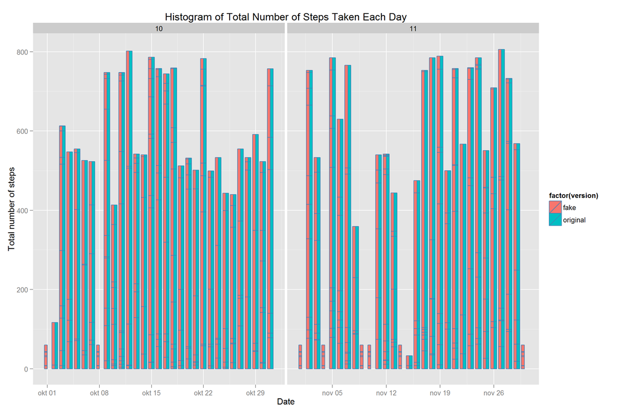

As such the differences do not look as big. Which goes to show that graphs do not always reveal all (or that I should have chosen another graph for this illustration).

## Are there differences in activity patterns between weekdays and weekends?

For this part the dataset with the filled-in missing values was used as instructed.

##### 1. Create a new factor variable in the dataset with two levels - “weekday” and “weekend” indicating whether a given date is a weekday or weekend day.

##### 2. Make a panel plot containing a time series plot (i.e. type = “l”) of the 5-minute interval (x-axis) and the average number of steps taken, averaged across all weekday days or weekend days (y-axis).

[figure not shown]